# Reproducible workflows in R

Practical

Author

Affiliation

Dr Ewan Carr

Department of Biostatistics & Health Informatics  
King’s College London

Published

July 25, 2025

# Welcome

This practical will bring together the steps covered in the lecture by:

1. Building a reproducible R pipeline
2. Committing your project to GitHub
3. Restoring it from GitHub

With the **Women’s EURO 2025** final approaching this weekend, we’ll build a reproducible pipeline to predict England’s chance of winning the final against Spain, using information on their performance over the past year.

You will:

- Build models to predict England’s chance of winning their next match.
- Simulate the likely outcome of the final.
- Use `here` for file paths and `renv` to lock package versions.
- Create a Git repository, version your code with git, and push it to GitHub.
- Make the project fully reproducible and shareable.

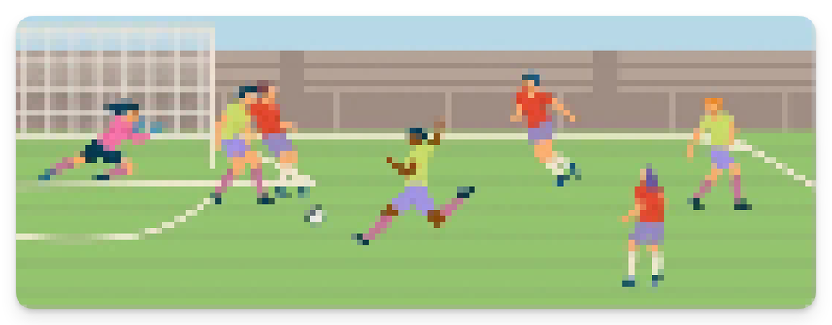

# Setup

## Software

To complete this practical, you’ll need:

- R (≥ 4.3)
- RStudio
- Git, used for version control
- [GitHub Desktop](https://github.com/apps/desktop) (optional), a user-friendly way to interact with Git and GitHub.

GitHub Desktop includes Git, so you don’t need to install Git separately if you use it. However, we recommend installing Git directly to ensure compatibility with RStudio’s Git features.

## Installing Git

**💡If you’re new to the command line, use GitHub Desktop**

[GitHub Desktop](https://github.com/apps/desktop) provides a simple interface for common tasks like committing, pushing, and pulling code — no terminal required. It’s a good starting point if you’re unfamiliar with the command line.

**macOS**

Git is often pre-installed on macOS. You can check by typing in the Terminal:

```bash
git --version
```

If it’s not installed, run:

```bash
xcode-select --install
```

You can optionally install GitHub Desktop, a graphical interface for Git and GitHub, by following the [instructions here](https://desktop.github.com).

**Windows**

You can download Git for Windows from https://git-scm.com. Run the installer and accept default options, in particular:

> *“Use Git from the command line and also from 3rd-party software”*

You can optionally install GitHub Desktop, a graphical interface for Git and GitHub, by following the [instructions here](https://desktop.github.com).

## Authenticating with GitHub

To push and pull from GitHub, you need to authenticate. There are two options:

**GitHub Desktop**

- This is a good place to start if you’re new to Git.
- When you first log in via GitHub Desktop, it stores a token securely.
- You can clone, commit, push, and pull without dealing with passwords or keys.

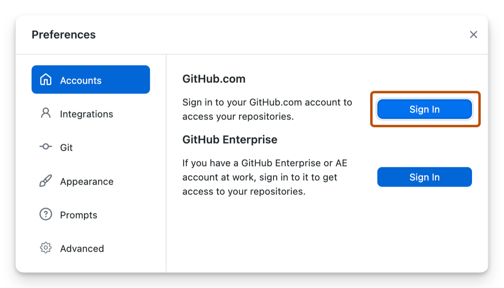

**SSH keys**

- Recommended for longer-term use.
- Requires access to a command line.
1. Generate a key (if you don’t have one):

```bash
ssh-keygen -t ed25519 -C "your_email@example.com"
```

2. Copy the key to your clipboard

```bash
# macOS
pbcopy < ~/.ssh/id_ed25519.pub

# Windows using Git Bash
cat ~/.ssh/id_ed25519.pub | clip
```

3. Add it to GitHub:
- Go to [GitHub → Settings → SSH and GPG keys](https://github.com/settings/keys).
- Click **New SSH key** and paste your generated key.
4. Tell Git to use the key:

```bash
git remote set-url origin git@github.com:username/repo.git
```

# 1 Create a project in RStudio

Create a new RStudio Project and give it an appropriate name (e.g., `euros-prediction`):

> `File` → `New Project` → `New Directory`

# 2 Download the scripts and datasets

Click the links below to download the required scripts and dataset:

- [`01-clean.R`](https://github.com/ewancarr/reproducible-r/raw/32c5193f823d03da27e59345169da15c68e12036/practical/2-scripts/01-clean.R)
- [`02-analysis.R`](https://github.com/ewancarr/reproducible-r/raw/refs/heads/main/practical/2-scripts/02-analysis.R)
- [`03-plot.R`](https://github.com/ewancarr/reproducible-r/raw/refs/heads/main/practical/2-scripts/03-plot.R)
- [`fixtures.csv`](https://raw.githubusercontent.com/ewancarr/reproducible-r/refs/heads/main/practical/1-data/raw/fixtures.csv)

Put these inside your project folder and recreate the structure shown below:

```
1-data/
├── raw/
│   └── fixtures.csv
└── clean/
2-scripts/
├── 01-clean.R
├── 02-analysis.R
└── 03-plot.R
outputs/
```

# 3 Initialise `renv` and install the required packages

In the console, type:

```r
install.packages("renv")
renv::init()
renv::install()
renv::snapshot()
```

**1**

Install the `renv` package. You only need to do this once—not for each project.

**2**

Initialise `renv` for the current project.

**3**

Install packages required for this project.

**4**

Save the current state into `renv.lock`.

Open the `renv.lock` lockfile to understand its contents.

# 4 Run the three scripts

Once packages are installed and `renv` is initialised, you’re ready to run the analysis.

**Import and clean data**

Run `01-clean.R` in RStudio. This script:

1. Imports the `fixtures.csv` dataset from the `1-data/raw` folder.
2. Performs data cleaning, adding venue, Elo ratings, rest days, and form.
3. Saves a cleaned dataset to `1-data/clean/fixtures.rds`.

**Predict the next match**

Run `02-analysis.R` in RStudio. This script:

1. Fits two Poisson regression models to predict:
   - England’s goals
   - Opponent’s goals
2. Simulates 1000 match results
3. Saves the probabilities to `outputs/results.rds`

**Visualise**

Run `03-plot.R` in RStudio. This script:

1. Loads the saved probabilities (`outputs/results.rds`).
2. Creates a bar chart of predicted win/draw/loss.
3. Saves the figure to `outputs/prediction_plot.png`.

# 5 Putting it all together

Create a new script `run.R` at the project root with the contents:

```
run.R
```

```r
library(here)
source(here("2-scripts", "01-clean.R"))
source(here("2-scripts", "02-analysis.R"))
source(here("2-scripts", "03-plot.R"))
```

This script uses [`source`](https://stat.ethz.ch/R-manual/R-devel/library/base/html/source.html) to run the three scripts sequentially, avoiding the need to run them separately.

Run the `run.R` script either by clicking `Run` or by typing at the console:

```r
source("run.R")
```

# 6 Initialise the Git repository

We’ve now set up our project, initialised `renv`, and created a `run.R` script that automates our data cleaning and analysis.

In this section, we’ll initialise a Git repository and ‘commit’ the current state of our files. Git will allow us to track changes to our files over time and restore previous versions.

You can complete this section via the terminal or using a desktop application, such as [GitHub Desktop](https://desktop.github.com/download/).

**Terminal**

Open a terminal in the project root and type:

```bash
git init
```

- You can do this from within RStudio in the ‘Terminal’ pane.
- If you haven’t yet installed Git, see the instructions above.

**GitHub Desktop**

1. Open GitHub Desktop.
2. Go to **File** → **Add Local Repository…**.
3. Click **Choose…** and select your existing project folder.
4. You should see the prompt:

> The directory does not appear to be a Git repository. Would you like to create a repository here instead?”
5. Click “Create Repository”.

# 7 Commit files to the local repository

Having initialised the empty repository, we now need to add our files.

**Terminal**

```bash
git add 1-data/*
git add 2-scripts/*
git add run.R
git add renv.lock
git add euros-prediction.Rproj
git commit -m "Initial commit"
```

**1**

Add all files in the ‘1-data’ folder.

**2**

Add all files in the ‘2-scripts’ folder.

**3**

Add the `run.R` script.

**4**

Add the `renv.lock` lockfile.

**5**

Add your RStudio Project file; change the name as appropriate.

**6**

Commit the new files with a short message (specified by `-m`)

**GitHub Desktop**

1. Open **GitHub Desktop** and select your repository.
2. In the **Changes** tab, tick the checkboxes to stage the following:
   - All files in the `1-data/` folder
   - All files in the `2-scripts/` folder
   - The `run.R` file
   - The `renv.lock` file
3. At the bottom left, enter a commit message: `Initial commit`
4. Click **Commit to main**.

# 8 Create an empty repository on GitHub

1. If you haven’t already, create an account on [GitHub.com](https://github.com).
2. Then, go to https://github.com/new and create a new, empty repository with an appropriate name (e.g., `euros-prediction`)

# 9 Connect our local repository to GitHub

We then need to connect your local repository with one you just created on GitHub.

**GitHub Desktop**

1. On GitHub.com, create a new (empty) repository.
2. In **GitHub Desktop**, go to **Repository** → **Repository Settings…**
3. Under **Remote**, click **Add** and enter:
   - **Name**: `origin`
   - **URL**: `git@github.com:username/repo.git` (Replace with the URL of your new repository)
4. Click **Save**.
5. Back in the main window, click **Push origin** (top bar) to upload your commits to GitHub.

**Terminal**

In the terminal, you can do this by typing:

```bash
git remote add origin git@github.com:username/repo.git
git push origin main
```

**1**

Set the `remote` to point to the new repository on Github. You will need to replace the URL with the corresponding URL for your repository.

**2**

‘Push’ the local history to GitHub.

# 10 Reproducing your analysis from GitHub

We’ll now test that we can recreate our analysis from the online repository. This ensures your project can be reliably re-run on another computer or by another user.

The steps involved are:

1. ‘Clone’ the existing repository from GitHub.
2. Restore the `renv` environment.
3. Run the `run.R` script to repeat the analysis.

**GitHub Desktop**

1. `File` → `Clone Repository…`
2. Choose your repository.

Then open the RStudio Project, and at the R console:

```r
renv::restore()
source("run.R")
```

**Terminal**

In the terminal:

```bash
git clone https://github.com/username/your-repo.git
```

**1**

‘Clone’ the repository on GitHub to a local folder. Replace `username` and `your-repo` as appropriate.

Then open the RStudio Project, and at the R console:

```r
renv::restore()
source("run.R")
```

# 11 Adding a ‘README’ file

1. Write a `README.md`[^1] file in your project folder. Briefly describe the analysis and steps needed to reproduce.
2. Add and commit this file to your local repository.
3. Push the changes to GitHub.

Once pushed, you can view the `README.md` on your repository page on GitHub.

## Footnotes

[^1]: Read [this](https://www.makeareadme.com) if you’re not sure how to start.